# Tugas Pertemuan 6 & 7: Pemodelan ARIMA - Pendugaan Parameter, Diagnostik Model, dan Peramalan

Audryna Khairunnisa Wibisono

2026-09-26

# Packages

```r
library(ggplot2)
library(tseries)
library(MASS)
library(forecast)
library(TSA)
library(TTR)
library(aTSA)
library(graphics)
library(readxl)
library(tsibble)
```

# Data

```r
library(readxl)
data <- read_excel("Air Quality Historical (Data Individu).xlsx")
data
```

```
## # A tibble: 156 × 3
##        t Tanggal    `PM2.5 (ug/m3)`
##    <dbl> <chr>                <dbl>
##  1     1 2025-04-13            55.3
##  2     2 2025-04-14            38.1
##  3     3 2025-04-15            66.5
##  4     4 2025-04-16            71.4
##  5     5 2025-04-17            85.9
##  6     6 2025-04-18            78.7
##  7     7 2025-04-19            52.8
##  8     8 2025-04-20            47.4
##  9     9 2025-04-21            66.6
## 10    10 2025-04-22            58.5
## # ℹ 146 more rows
```

```r
data.ts <- ts(data$`PM2.5 (ug/m3)`)

n_total <- length(data.ts)
n_train <- round(0.8 * n_total) # 125

train.ts <- data.ts[1:n_train]
test.ts  <- data.ts[(n_train + 1):n_total]

train.ts <- ts(train.ts)
test.ts  <- ts(test.ts)
```

# Eksplorasi Data

## Plot Data Penuh

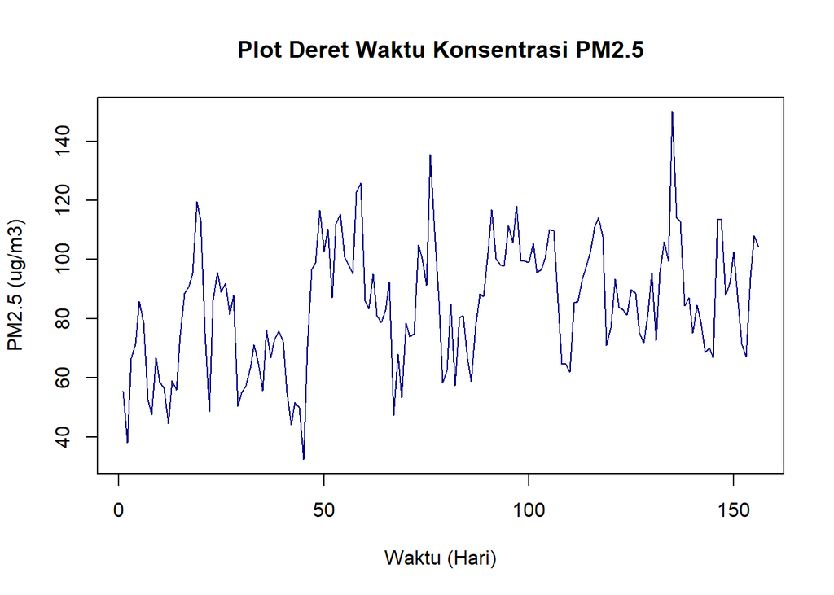

```r
plot.ts(data.ts,
        col = "navyblue",
        lty = 1,
        xlab = "Waktu (Hari)",
        ylab = "PM2.5 (ug/m3)",
        main = "Plot Deret Waktu Konsentrasi PM2.5")
```

Berdasarkan plot data deret waktu di atas, terlihat bahwa data cenderung **stasioner dalam rataan** karena bergerak di sekitar nilai tengahnya tanpa tren naik/turun yang jelas. Data juga **stasioner dalam ragam** karena lebar pitanya relatif seragam. Berdasarkan pola tersebut, pembagian data latih dan data uji ditetapkan dengan proporsi **80%:20%** (125 data latih dan 31 data uji).

## Plot Data Latih

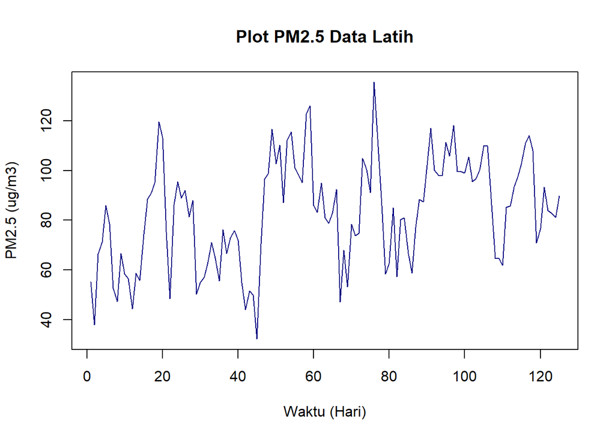

```r
plot.ts(train.ts,
        col = "navyblue",
        lty = 1,
        xlab = "Waktu (Hari)",
        ylab = "PM2.5 (ug/m3)",
        main = "Plot PM2.5 Data Latih")
```

Berdasarkan plot data deret waktu pada data latih, terlihat bahwa data berfluktuasi secara konstan di sekitar nilai tengahnya tanpa menunjukkan adanya tren naik atau turun yang signifikan. Hal ini mengindikasikan bahwa data latih cenderung stasioner dalam rataan.

## Plot Data Uji

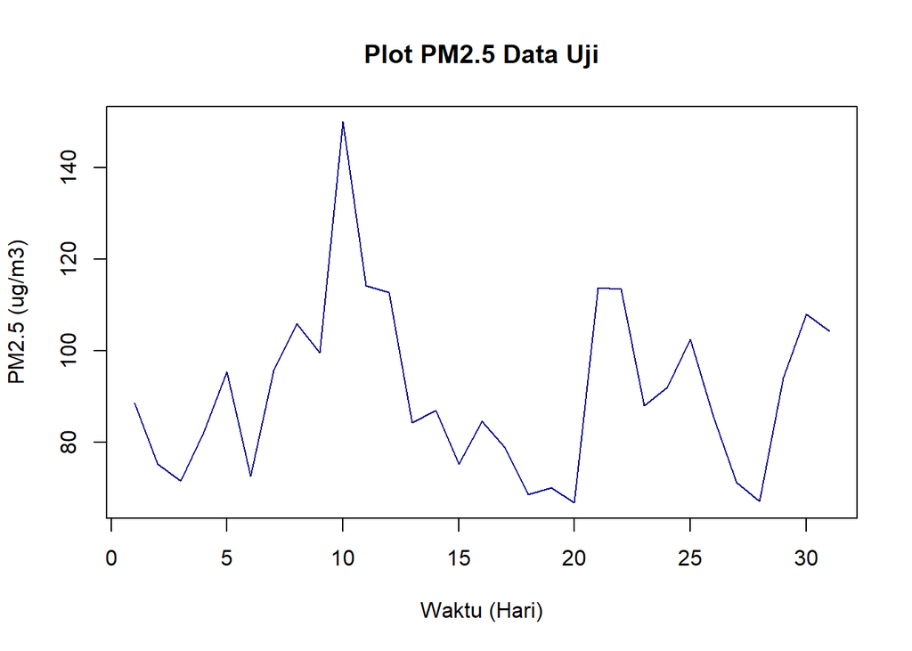

```r
plot.ts(test.ts,
        col = "navyblue",
        lty = 1,
        xlab = "Waktu (Hari)",
        ylab = "PM2.5 (ug/m3)",
        main = "Plot PM2.5 Data Uji")
```

# Uji Stasioneritas Data

## Plot ACF

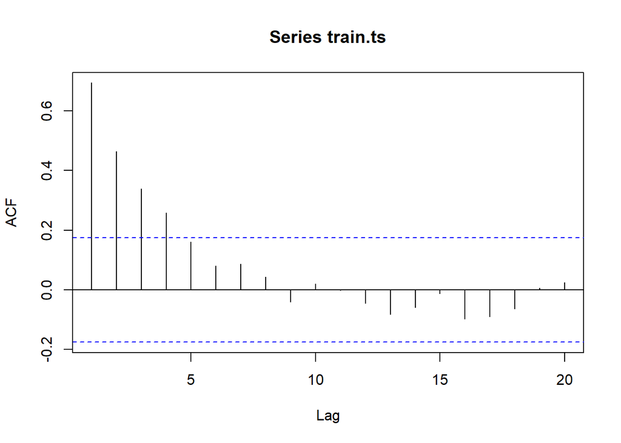

```r
acf(train.ts)
```

Berdasarkan plot ACF, terlihat bahwa nilai autokorelasi menurun secara bertahap (*tails off*) seiring bertambahnya lag dan semakin mendekati nol setelah lag awal. Hal ini menandakan bahwa data stasioner dalam rataan.

## Uji ADF

```r
tseries::adf.test(train.ts)
```

```
##
##  Augmented Dickey-Fuller Test
##
## data:  train.ts
## Dickey-Fuller = -4.1058, Lag order = 4, p-value = 0.01
## alternative hypothesis: stationary
```

$H_0$ : Data tidak stasioner dalam rataan

$H_1$ : Data stasioner dalam rataan

Berdasarkan uji ADF tersebut, didapat *p-value* sebesar 0.01 yang lebih kecil dari taraf nyata 5% sehingga tolak $H_0$. Hal ini menandakan bahwa data stasioner dalam rataan sehingga tidak memerlukan proses differencing ($d = 0$).

## Plot Box-Cox

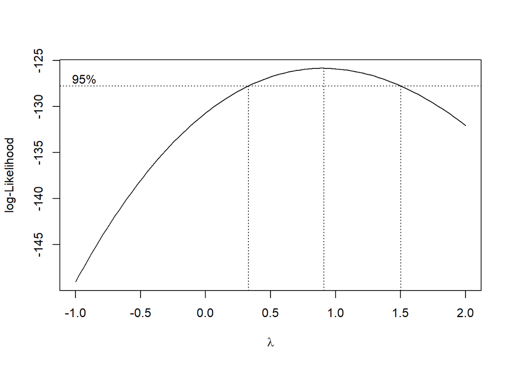

```r
# Membuat indeks urutan waktu sesuai panjang data latih
index <- seq(1:length(train.ts))

# Uji Box-Cox
bc <- boxcox(train.ts ~ index, lambda = seq(-1, 2, by = 0.1))
```

```r
# Nilai lambda optimum
lambda_opt <- bc$x[which.max(bc$y)]
lambda_opt
```

```
## [1] 0.9090909
```

```r
# Selang kepercayaan 95% untuk lambda
ci_lambda <- bc$x[bc$y > max(bc$y) - 0.5 * qchisq(0.95, df = 1)]

# Batas bawah dan batas atas
ci_lower <- min(ci_lambda)
ci_upper <- max(ci_lambda)

c(Batas_Bawah = ci_lower, Batas_Atas = ci_upper)
```

```
## Batas_Bawah  Batas_Atas
##   0.3333333   1.4848485
```

Berdasarkan plot Box-Cox, diperoleh nilai lambda optimum sekitar 0,9–1,0 dengan selang kepercayaan 95% yang mencakup nilai 1. Karena nilai 1 berada dalam selang kepercayaan, data dapat dianggap stasioner dalam ragam sehingga tidak diperlukan transformasi Box-Cox.

# Identifikasi Model

### Plot ACF

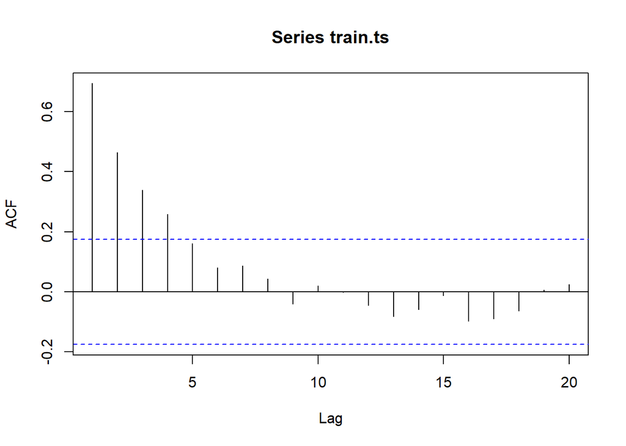

```r
acf(train.ts)
```

Berdasarkan plot ACF, terlihat bahwa nilai autokorelasi menurun secara bertahap (*tails off*) seiring bertambahnya lag dan semakin mendekati nol setelah lag awal. Hal ini menandakan bahwa data stasioner dalam rataan.

## Plot PACF

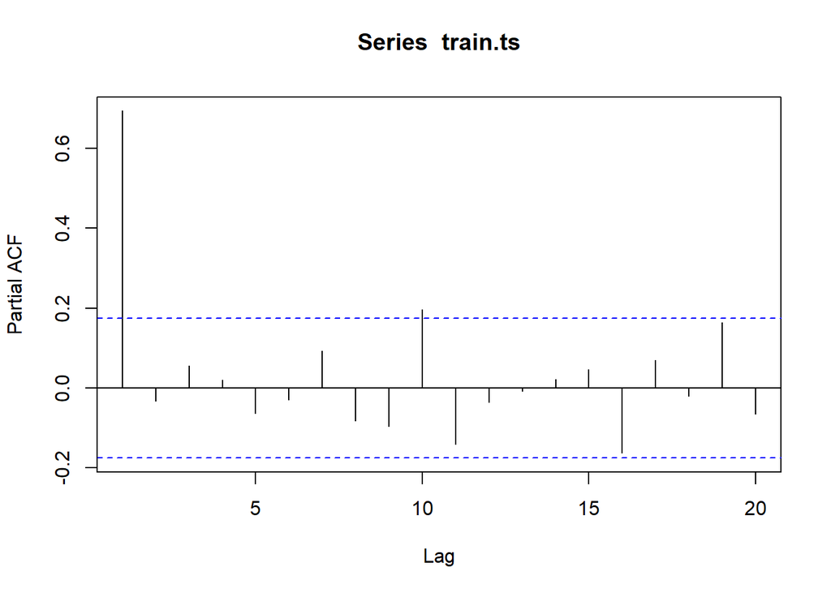

```r
pacf(train.ts)
```

Berdasarkan plot tersebut, terlihat bahwa plot PACF cenderung *cuts off* pada lag ke 1, sehingga jika plot ACF dianggap *tails off*, maka model tentatifnya adalah ARIMA(1,0,0).

Jika baik plot ACF maupun plot PACF keduanya dianggap tails of, maka model yang terbentuk adalah ARIMA(1,0,1)

## Plot EACF

```r
eacf(train.ts)
```

```
## AR/MA
##   0 1 2 3 4 5 6 7 8 9 10 11 12 13
## 0 x x x x o o o o o o o  o  o  o
## 1 o o o o o o o o o o o  o  o  o
## 2 x o o o o o o o o o o  o  o  o
## 3 x x o o o o o o o o o  o  o  o
## 4 x x x o o o o o o o o  o  o  o
## 5 x x o o o o o o o o o  o  o  o
## 6 x x x o x o o o o o o  o  o  o
## 7 x x o o o o o o o o o  o  o  o
```

Identifikasi model menggunakan plot EACF dilakukan dengan melihat ujung segitiga pada pola segitiga nol. Dalam hal ini model tentatif yang terbentuk adalah ARIMA(1,0,0), ARIMA(2,0,1), ARIMA(3,0,2), ARIMA(4,0,3), dan ARIMA(0,0,4).

# Pendugaan Parameter Model Tentatif

## ARIMA(1,0,0)

```r
model1.pm25=Arima(train.ts, order=c(1,0,0),method="ML")
summary(model1.pm25) #AIC=1042.96
```

```
## Series: train.ts
## ARIMA(1,0,0) with non-zero mean
##
## Coefficients:
##          ar1     mean
##       0.6981  82.7412
## s.e.  0.0637   4.4448
##
## sigma^2 = 237.1:  log likelihood = -518.48
## AIC=1042.96   AICc=1043.16   BIC=1051.44
##
## Training set error measures:
##                     ME     RMSE      MAE       MPE     MAPE     MASE       ACF1
## Training set 0.2152517 15.27507 12.03437 -3.981865 16.58352 0.956683 0.01331255
```

```r
lmtest::coeftest(model1.pm25) #seluruh parameter signifikan
```

```
##
## z test of coefficients:
##
##            Estimate Std. Error z value  Pr(>|z|)
## ar1        0.698057   0.063674  10.963 < 2.2e-16 ***
## intercept 82.741227   4.444763  18.615 < 2.2e-16 ***
## ---
## Signif. codes:  0 '***' 0.001 '**' 0.01 '*' 0.05 '.' 0.1 ' ' 1
```

## ARIMA(2,0,1)

```r
model2.pm25=Arima(train.ts, order=c(2,0,1),method="ML")
summary(model2.pm25) #AIC=1046.86
```

```
## Series: train.ts
## ARIMA(2,0,1) with non-zero mean
##
## Coefficients:
##          ar1     ar2     ma1     mean
##       0.2867  0.2736  0.4293  82.7745
## s.e.  1.5451  1.0928  1.5276   4.3666
##
## sigma^2 = 240.8:  log likelihood = -518.43
## AIC=1046.86   AICc=1047.36   BIC=1061
##
## Training set error measures:
##                     ME     RMSE      MAE       MPE     MAPE      MASE
## Training set 0.2043691 15.26897 12.03879 -3.997455 16.60265 0.9570343
##                     ACF1
## Training set -0.00369841
```

```r
lmtest::coeftest(model2.pm25) #terdapat parameter tidak signifikan
```

```
##
## z test of coefficients:
##
##           Estimate Std. Error z value Pr(>|z|)
## ar1        0.28675    1.54512  0.1856   0.8528
## ar2        0.27359    1.09281  0.2504   0.8023
## ma1        0.42932    1.52761  0.2810   0.7787
## intercept 82.77448    4.36659 18.9563   <2e-16 ***
## ---
## Signif. codes:  0 '***' 0.001 '**' 0.01 '*' 0.05 '.' 0.1 ' ' 1
```

## ARIMA(3,0,2)

```r
model3.pm25=Arima(train.ts, order=c(3,0,2),method="ML")
summary(model3.pm25) #AIC=1044.75
```

```
## Series: train.ts
## ARIMA(3,0,2) with non-zero mean
##
## Coefficients:
##          ar1      ar2     ar3     ma1     ma2     mean
##       0.5291  -0.8312  0.7119  0.1798  0.9327  82.5907
## s.e.  0.0951   0.0509  0.0656  0.1040  0.0941   4.6621
##
## sigma^2 = 232:  log likelihood = -515.37
## AIC=1044.75   AICc=1045.7   BIC=1064.55
##
## Training set error measures:
##                     ME     RMSE      MAE      MPE     MAPE      MASE
## Training set 0.2413378 14.86065 11.99037 -3.75345 16.44996 0.9531852
##                     ACF1
## Training set 0.008690365
```

```r
lmtest::coeftest(model3.pm25) #terdapat parameter tidak signifikan
```

```
##
## z test of coefficients:
##
##            Estimate Std. Error  z value  Pr(>|z|)
## ar1        0.529080   0.095068   5.5653 2.617e-08 ***
## ar2       -0.831171   0.050912 -16.3258 < 2.2e-16 ***
## ar3        0.711922   0.065555  10.8599 < 2.2e-16 ***
## ma1        0.179758   0.104034   1.7279   0.08401 .
## ma2        0.932707   0.094085   9.9135 < 2.2e-16 ***
## intercept 82.590654   4.662134  17.7152 < 2.2e-16 ***
## ---
## Signif. codes:  0 '***' 0.001 '**' 0.01 '*' 0.05 '.' 0.1 ' ' 1
```

## ARIMA(4,0,3)

```r
model4.pm25=Arima(train.ts, order=c(4,0,3),method="ML")
summary(model4.pm25) #AIC=1049.05
```

```
## Series: train.ts
## ARIMA(4,0,3) with non-zero mean
##
## Coefficients:
##           ar1      ar2     ar3     ar4     ma1     ma2     ma3     mean
##       -0.0208  -0.4239  0.5219  0.1465  0.7458  0.9349  0.0757  82.6177
## s.e.   0.6036   0.1948  0.3205  0.3629  0.6052  0.4534  0.5495   4.6386
##
## sigma^2 = 236.8:  log likelihood = -515.53
## AIC=1049.05   AICc=1050.62   BIC=1074.51
##
## Training set error measures:
##                     ME     RMSE      MAE       MPE     MAPE      MASE
## Training set 0.2269893 14.88864 12.00252 -3.738776 16.43464 0.9541512
##                     ACF1
## Training set 0.001855254
```

```r
lmtest::coeftest(model4.pm25) #terdapat parameter tidak signifikan
```

```
##
## z test of coefficients:
##
##            Estimate Std. Error z value Pr(>|z|)
## ar1       -0.020753   0.603644 -0.0344  0.97257
## ar2       -0.423917   0.194830 -2.1758  0.02957 *
## ar3        0.521889   0.320522  1.6282  0.10347
## ar4        0.146492   0.362874  0.4037  0.68643
## ma1        0.745797   0.605181  1.2324  0.21782
## ma2        0.934924   0.453432  2.0619  0.03922 *
## ma3        0.075740   0.549522  0.1378  0.89038
## intercept 82.617737   4.638615 17.8109  < 2e-16 ***
## ---
## Signif. codes:  0 '***' 0.001 '**' 0.01 '*' 0.05 '.' 0.1 ' ' 1
```

## ARIMA(0,0,4)

```r
model5.pm25=Arima(train.ts, order=c(0,0,4),method="ML")
summary(model5.pm25) #AIC=1051.55
```

```
## Series: train.ts
## ARIMA(0,0,4) with non-zero mean
##
## Coefficients:
##          ma1     ma2     ma3     ma4     mean
##       0.6925  0.4242  0.2668  0.1393  82.9642
## s.e.  0.0901  0.1010  0.1084  0.0763   3.4532
##
## sigma^2 = 248.3:  log likelihood = -519.78
## AIC=1051.55   AICc=1052.27   BIC=1068.52
##
## Training set error measures:
##                     ME     RMSE     MAE       MPE     MAPE      MASE       ACF1
## Training set 0.1288002 15.43916 12.2414 -4.417445 16.93531 0.9731409 0.02575424
```

```r
lmtest::coeftest(model5.pm25) #terdapat parameter tidak signifikan
```

```
##
## z test of coefficients:
##
##            Estimate Std. Error z value  Pr(>|z|)
## ma1        0.692539   0.090132  7.6836 1.546e-14 ***
## ma2        0.424233   0.100965  4.2018 2.648e-05 ***
## ma3        0.266837   0.108370  2.4623   0.01381 *
## ma4        0.139259   0.076332  1.8244   0.06809 .
## intercept 82.964250   3.453197 24.0253 < 2.2e-16 ***
## ---
## Signif. codes:  0 '***' 0.001 '**' 0.01 '*' 0.05 '.' 0.1 ' ' 1
```

## Ringkasan AIC

```r
model_tentatif <- data.frame(
  Model = c("ARIMA(1,0,0)",
            "ARIMA(2,0,1)",
            "ARIMA(3,0,2)",
            "ARIMA(4,0,3)",
            "ARIMA(0,0,4)"),
  AIC = c(
    AIC(model1.pm25),
    AIC(model2.pm25),
    AIC(model3.pm25),
    AIC(model4.pm25),
    AIC(model5.pm25)
  ),
  BIC = c(
    BIC(model1.pm25),
    BIC(model2.pm25),
    BIC(model3.pm25),
    BIC(model4.pm25),
    BIC(model5.pm25)
  )
)

model_tentatif
```

```
##          Model      AIC      BIC
## 1 ARIMA(1,0,0) 1042.958 1051.443
## 2 ARIMA(2,0,1) 1046.859 1061.001
## 3 ARIMA(3,0,2) 1044.747 1064.545
## 4 ARIMA(4,0,3) 1049.052 1074.506
## 5 ARIMA(0,0,4) 1051.554 1068.524
```

Berdasarkan pendugaan parameter di atas, nilai AIC terkecil dimiliki oleh model ARIMA(1,0,0) dan parameter model ARIMA(1,0,0) juga seluruhnya signifikan sehingga model yang dipilih adalah model ARIMA(1,0,0).

# Analisis Sisaan

Model terbaik hasil identifikasi kemudian dicek asumsi sisaannya. Sisaan model ARIMA harus memenuhi asumsi normalitas, kebebasan sisaan, dan kehomogenan ragam. Diagnostik model dilakukan secara eksplorasi dan uji formal.

## Eksplorasi Sisaan

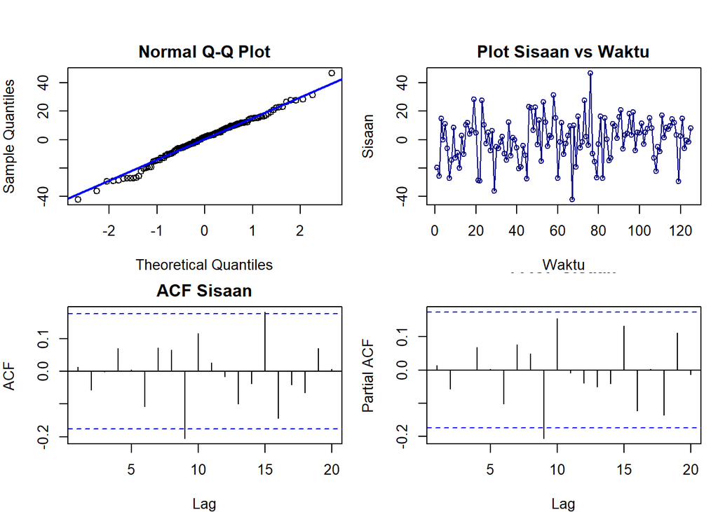

```r
# Ambil sisaan/residual dari model terbaik
sisaan.pm25 <- model1.pm25$residuals

# Pengaturan grid plot 2x2
par(mfrow = c(2,2),
    mar = c(4,4,2,1),
    oma = c(0,0,2,0))

# 1. Q-Q Plot
qqnorm(sisaan.pm25, main = "Normal Q-Q Plot")
qqline(sisaan.pm25, col = "blue", lwd = 2)

# 2. Plot Sisaan vs Waktu
plot(sisaan.pm25, type = "o", col = "navyblue",
     main = "Plot Sisaan vs Waktu",
     xlab = "Waktu", ylab = "Sisaan")

# 3. ACF Sisaan
acf(sisaan.pm25, main = "ACF Sisaan")

# 4. PACF Sisaan
pacf(sisaan.pm25, main = "PACF Sisaan")
```

```r
# Mengembalikan layout plot ke 1x1
par(mfrow = c(1,1))
```